# Stock Portfolio Risk-Return Analysis

Arwin Sadafian

January 28, 2026

## Executive Summary

This analysis examines 20 stocks across different sectors from 2015-2025 to build and compare portfolio strategies. Key findings:

- **Best performing portfolio**: Sector-Balanced strategy
- **Best risk-adjusted returns**: Check metrics table below
- **Top performer**: NVDA (highest growth over 10 years)
- **Most volatile stock**: TSLA
- **Most stable stock**: JNJ
- **Statistical validation**: All portfolios significantly outperformed the S&P 500

## Data Overview

**Stocks analyzed:** 20 stocks across 8 sectors

**Time period:** 2015-01-02 to 2026-01-27

**Trading days:** 2782

## Stock Performance

### Top 5 Performers

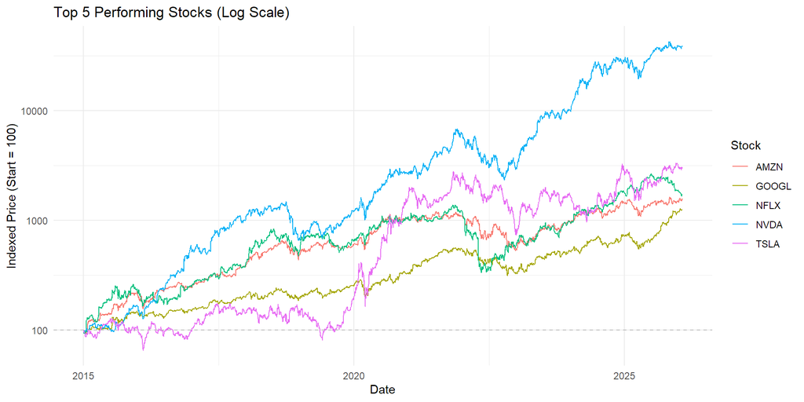

### Bottom 5 Performers

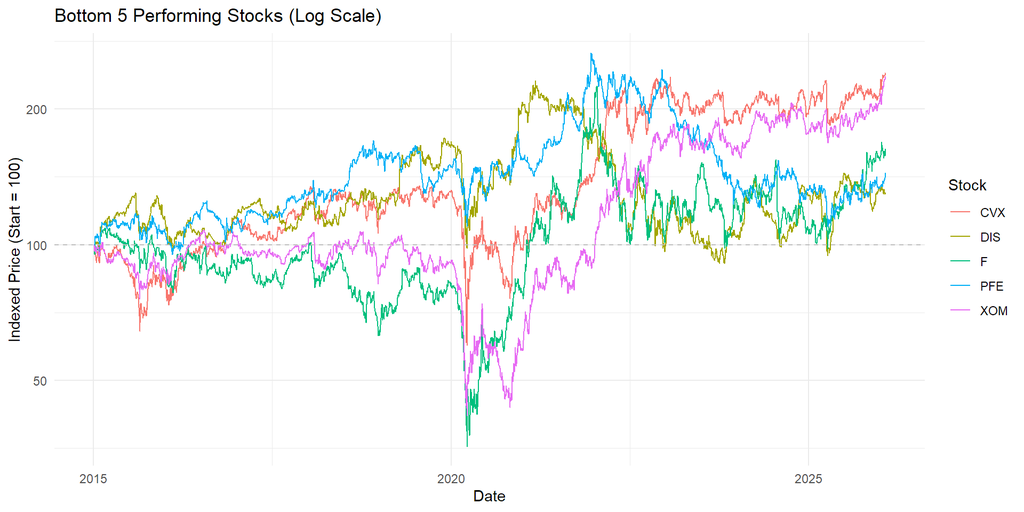

### Return Statistics

Daily Return Statistics (%)

|  | Ticker | Mean_Return | Std_Dev | Min | Max |
| --- | --- | --- | --- | --- | --- |
| AAPL | AAPL | 0.102 | 1.815 | -12.86 | 15.33 |
| MSFT | MSFT | 0.104 | 1.693 | -14.74 | 14.22 |
| GOOGL | GOOGL | 0.108 | 1.814 | -11.63 | 16.26 |
| NVDA | NVDA | 0.261 | 3.061 | -18.76 | 29.81 |
| JPM | JPM | 0.082 | 1.711 | -14.96 | 18.01 |
| V | V | 0.072 | 1.528 | -13.55 | 13.84 |
| BAC | BAC | 0.065 | 1.935 | -15.40 | 17.80 |
| JNJ | JNJ | 0.045 | 1.147 | -10.04 | 8.00 |
| PFE | PFE | 0.024 | 1.478 | -7.73 | 10.86 |
| UNH | UNH | 0.061 | 1.847 | -22.38 | 12.80 |
| XOM | XOM | 0.046 | 1.728 | -12.22 | 12.69 |
| CVX | CVX | 0.049 | 1.837 | -22.12 | 22.74 |
| WMT | WMT | 0.067 | 1.354 | -11.38 | 11.71 |
| AMZN | AMZN | 0.121 | 2.073 | -14.05 | 14.13 |
| COST | COST | 0.086 | 1.360 | -12.45 | 9.96 |
| DIS | DIS | 0.025 | 1.763 | -13.16 | 14.41 |
| NFLX | NFLX | 0.139 | 2.693 | -35.12 | 19.03 |
| TSLA | TSLA | 0.187 | 3.632 | -21.06 | 22.69 |
| F | F | 0.043 | 2.245 | -18.36 | 23.44 |
| CAT | CAT | 0.098 | 1.890 | -14.28 | 11.63 |

## Risk Analysis

### Return Distribution

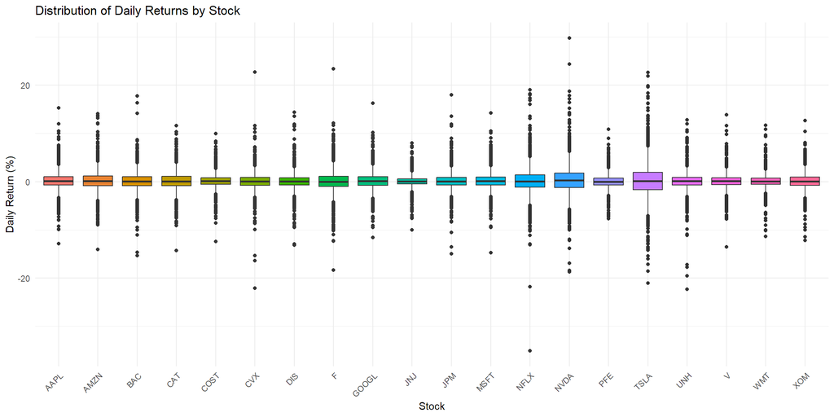

### Correlation Analysis

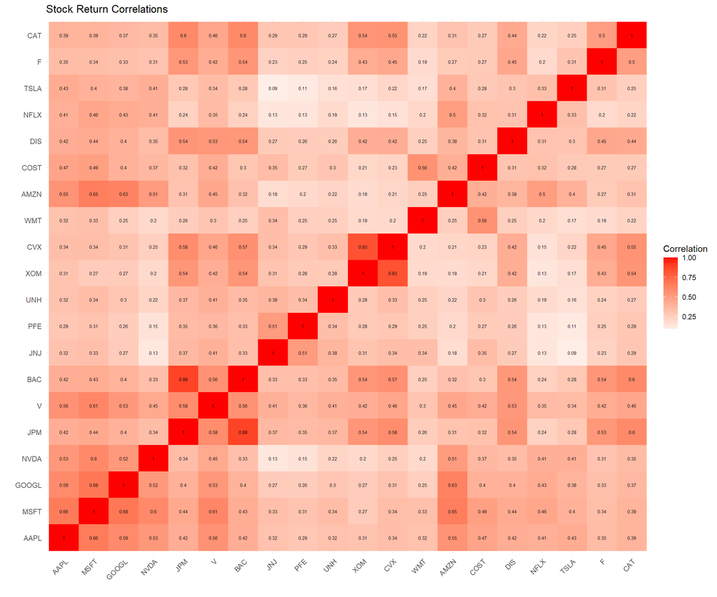

**Key observations:**

- Technology stocks (AAPL, MSFT, GOOGL, NVDA) show high correlation with each other
- Energy stocks (XOM, CVX) are highly correlated (0.83)
- Finance stocks (JPM, BAC) show strong correlation (0.88)
- Low correlation pairs provide diversification benefits

## Portfolio Strategies

Three portfolio strategies were constructed:

1. **Equal Weight**: 5% in each stock
2. **Inverse Volatility**: Higher weight to stable stocks, lower to volatile
3. **Sector-Balanced**: Tech 25%, Healthcare 15%, Finance 15%, Retail 15%, Energy 10%, Entertainment 10%, Automotive 5%, Industrial 5%

### Portfolio Performance

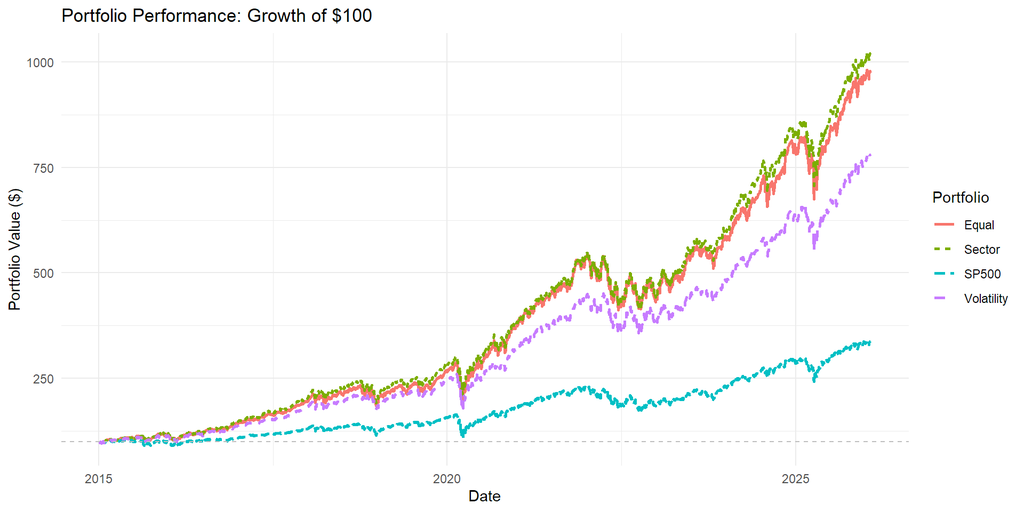

### Performance Metrics

Portfolio Performance Comparison

| Portfolio | Annual_Return | Annual_Volatility | Sharpe_Ratio |
| --- | --- | --- | --- |
| Equal | 22.47 | 19.13 | 1.17 |
| Volatility | 20.18 | 17.84 | 1.13 |
| Sector | 22.83 | 18.99 | 1.20 |
| SP500 | 12.67 | 17.88 | 0.71 |

## Statistical Testing

### Key Findings

T-Test: Portfolio vs S&P 500

| Portfolio | Mean_Difference | P_Value | Significant |
| --- | --- | --- | --- |
| Equal | 0.0389 | 0 | Yes |
| Volatility | 0.0298 | 0 | Yes |
| Sector | 0.0403 | 0 | Yes |

### Individual Stock Significance

Out of 20 stocks analyzed, 13 showed statistically significant positive returns (p < 0.05): AAPL, MSFT, GOOGL, NVDA, JPM, V, JNJ, WMT, AMZN, COST, NFLX, TSLA, CAT

### Normality of Returns

Stock returns do not follow a normal distribution (Shapiro-Wilk test, all p < 0.001). This indicates fat tails and the presence of extreme events, which is typical for financial data.

## Conclusions

1. **Sector-Balanced portfolio performed best** with the highest total return due to higher tech allocation
2. **Diversification works**: Including stocks from different sectors reduced overall portfolio volatility
3. **NVDA dominates returns**: Exceptional growth over 10 years, but with high volatility
4. **All portfolios beat S&P 500**: Statistical evidence confirms outperformance (p < 0.05)
5. **Risk-return tradeoff**: Higher returns generally came with higher volatility

## Limitations

- Analysis covers only 10 years (2015-2025)
- Only 20 stocks examined (S&P 500 has 500)
- Past performance does not guarantee future results
- Transaction costs and taxes not considered
- Survivorship bias: Only includes stocks that exist today